# 資料探勘

### 效能指標名詞解釋

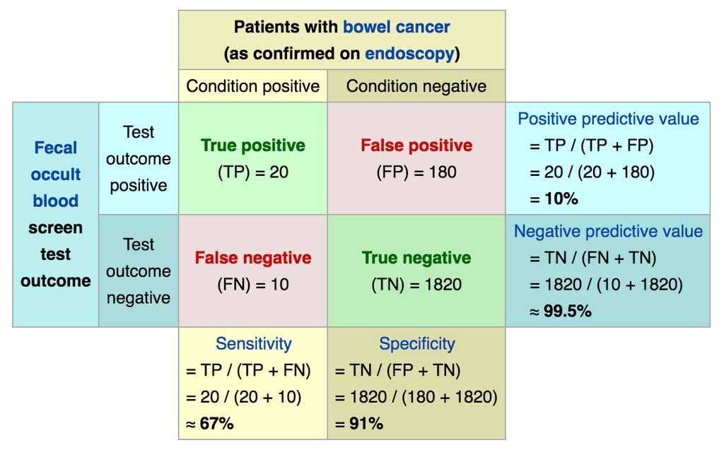

### 效能指標公式

當答案是二元時：效能指標公式

- Sensitivity 敏感性：所有`真的有病`的人，被`預測有病`的比例
- Specificity 特異性：所有`真的沒病`的人，被`預測沒病`的比例
- Positive Predictive Value (PPV) 陽性預測值：所有被`預測有病`的人，`真的有病`的比例
- Negative Predictive Value (NPV) 陰性預測值：所有被`預測沒病`的人，`真的沒病`的比例

### 效能指標

回想一下剛剛的驗證結果

```r
table(AdmitProb<0.5,mydata[mydata$Test==T,]$admit) # row,column
```

```
         1  0
  FALSE 35 82
  TRUE  12  4
```

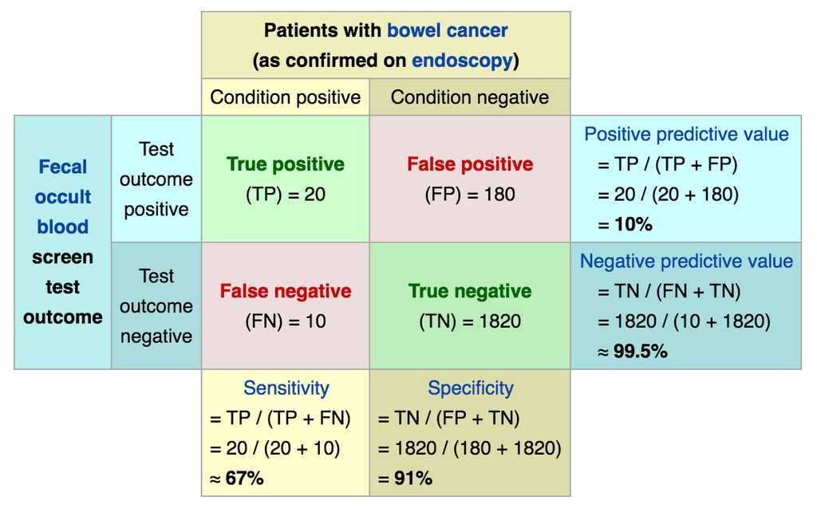

### 效能指標

計算預測效能參數

```r
AdmitProb<-predict(finalFit,
                   newdata = mydata[mydata$Test==T,], #Test==T, test data
                   type="response") #結果為每個人『不』被錄取的機率
AdmitAns<-factor(ifelse(AdmitProb<0.5,1,0),levels=c(1,0))
str(AdmitAns)
```

```
 Factor w/ 2 levels "1","0": 2 1 2 1 2 1 2 2 2 2 ...
 - attr(*, "names")= chr [1:133] "1" "3" "5" "6" ...
```

### 效能指標

計算預測效能參數

```r
library(caret) # install.packages("caret") #計算參數的packages
sensitivity(AdmitAns,mydata[mydata$Test==T,]$admit)
```

```
[1] 0.2553191
```

```r
specificity(AdmitAns,mydata[mydata$Test==T,]$admit)
```

```
[1] 0.9534884
```

```r
posPredValue(AdmitAns,mydata[mydata$Test==T,]$admit)
```

```
[1] 0.75
```

```r
negPredValue(AdmitAns,mydata[mydata$Test==T,]$admit)
```

```
[1] 0.7008547
```